# Multinomial logistic regression

Predicting red wine quality from chemical measurements

Kyle Costabile, Shiv Dutta, Alison Gu, Caroline Liu, Chris Zaragoza

PSTAT 197A, Fall 2026

# 1 Abstract

Multinomial logistic regression extends binary logistic regression to outcomes with more than two classes. We use it to predict whether a red wine is **poor**, **average**, or **good** from 11 chemical measurements. This vignette is for students who know binary logistic regression.

We will:

- explore the data and its class imbalance
- split and standardize the data
- fit the model with `nnet::multinom()` and interpret it
- evaluate predictions on a test set
- handle class imbalance and correlated predictors

# 2 Dataset

The data come from the [UCI Machine Learning Repository](https://archive.ics.uci.edu/dataset/186/wine+quality) (Cortez et al., 2009). Each row is a Portuguese red wine with 11 measurements and a quality score (0–10) from expert tasters.

| Variable | Description |
| --- | --- |
| `fixed acidity` | Tartaric acid (g/L) |
| `volatile acidity` | Acetic acid (g/L) |
| `citric acid` | Citric acid (g/L) |
| `residual sugar` | Sugar left after fermentation (g/L) |
| `chlorides` | Sodium chloride (g/L) |
| `free sulfur dioxide` | Free SO₂ (mg/L) |
| `total sulfur dioxide` | Free + bound SO₂ (mg/L) |
| `density` | Density (g/cm³) |
| `pH` | Acidity on the pH scale |
| `sulphates` | Potassium sulphate (g/L) |
| `alcohol` | Alcohol content (% vol) |
| `quality` | Expert quality score (0–10); response variable |

# 3 Setup

```r
library(ggplot2)     # plotting
library(nnet)        # multinom(): multinomial logistic regression
library(caret)       # confusionMatrix(), train()
library(tidymodels)  # loads dplyr, tidyr and yardstick
library(readr)       # read_csv()
library(pROC)        # roc(): ROC curves and AUC
```

```r
wine <- read_csv("data/winequality-red.csv", show_col_types = FALSE)
dim(wine)
```

```
## [1] 1599   12
```

```r
summary(wine)
```

```
##  fixed acidity   volatile acidity  citric acid    residual sugar
##  Min.   : 4.60   Min.   :0.1200   Min.   :0.000   Min.   : 0.900
##  1st Qu.: 7.10   1st Qu.:0.3900   1st Qu.:0.090   1st Qu.: 1.900
##  Median : 7.90   Median :0.5200   Median :0.260   Median : 2.200
##  Mean   : 8.32   Mean   :0.5278   Mean   :0.271   Mean   : 2.539
##  3rd Qu.: 9.20   3rd Qu.:0.6400   3rd Qu.:0.420   3rd Qu.: 2.600
##  Max.   :15.90   Max.   :1.5800   Max.   :1.000   Max.   :15.500
##    chlorides       free sulfur dioxide total sulfur dioxide    density
##  Min.   :0.01200   Min.   : 1.00       Min.   :  6.00       Min.   :0.9901
##  1st Qu.:0.07000   1st Qu.: 7.00       1st Qu.: 22.00       1st Qu.:0.9956
##  Median :0.07900   Median :14.00       Median : 38.00       Median :0.9968
##  Mean   :0.08747   Mean   :15.87       Mean   : 46.47       Mean   :0.9967
##  3rd Qu.:0.09000   3rd Qu.:21.00       3rd Qu.: 62.00       3rd Qu.:0.9978
##  Max.   :0.61100   Max.   :72.00       Max.   :289.00       Max.   :1.0037
##        pH          sulphates         alcohol         quality
##  Min.   :2.740   Min.   :0.3300   Min.   : 8.40   Min.   :3.000
##  1st Qu.:3.210   1st Qu.:0.5500   1st Qu.: 9.50   1st Qu.:5.000
##  Median :3.310   Median :0.6200   Median :10.20   Median :6.000
##  Mean   :3.311   Mean   :0.6581   Mean   :10.42   Mean   :5.636
##  3rd Qu.:3.400   3rd Qu.:0.7300   3rd Qu.:11.10   3rd Qu.:6.000
##  Max.   :4.010   Max.   :2.0000   Max.   :14.90   Max.   :8.000
```

There are 1599 wines. The predictors are on very different scales (density stays near 1, total sulfur dioxide reaches the hundreds), which we fix later.

## 3.1 Defining the outcome

Few wines get extreme scores, so we group them into three classes:

- **0 = poor**: score ≤ 5
- **1 = average**: score = 6
- **2 = good**: score ≥ 7

```r
wine$quality_group <- ifelse(wine$quality <= 5, 0,
                             ifelse(wine$quality <= 6, 1, 2))
wine$quality_group <- factor(wine$quality_group, levels = c(0, 1, 2))

# remove the raw score so it can't be used as a predictor
wine$quality <- NULL

table(wine$quality_group)
```

```
##
##   0   1   2
## 744 638 217
```

```r
prop.table(table(wine$quality_group))
```

```
##
##         0         1         2
## 0.4652908 0.3989994 0.1357098
```

# 4 Exploratory analysis

## 4.1 Missing data and duplicates

```r
colSums(is.na(wine))   # missing values per column
```

```
##        fixed acidity     volatile acidity          citric acid
##                    0                    0                    0
##       residual sugar            chlorides  free sulfur dioxide
##                    0                    0                    0
## total sulfur dioxide              density                   pH
##                    0                    0                    0
##            sulphates              alcohol        quality_group
##                    0                    0                    0
```

```r
sum(duplicated(wine))  # rows that repeat an earlier row
```

```
## [1] 240
```

There are no missing values. There are 240 duplicate rows, which we keep. Some may end up in both the training and test sets, which can make test results look slightly better.

## 4.2 Class balance

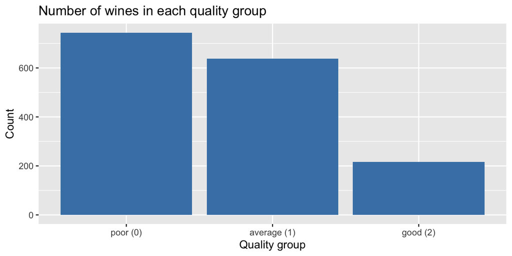

```r
ggplot(wine, aes(x = quality_group)) +
  geom_bar(fill = "steelblue") +
  scale_x_discrete(labels = c("0" = "poor (0)", "1" = "average (1)", "2" = "good (2)")) +
  labs(title = "Number of wines in each quality group",
       x = "Quality group", y = "Count")
```

Only 13.6% of wines are good. The model will likely struggle most with this class (Section 9), and we try a fix in Section 10.

## 4.3 Predictors by class

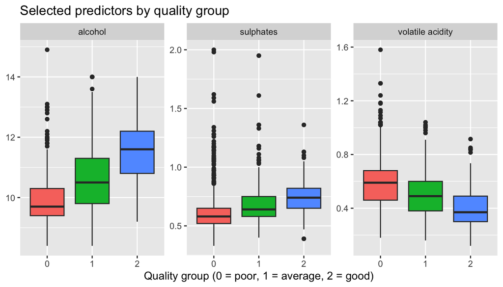

```r
wine %>%
  select(quality_group, alcohol, `volatile acidity`, sulphates) %>%
  pivot_longer(-quality_group, names_to = "predictor", values_to = "value") %>%
  ggplot(aes(x = quality_group, y = value, fill = quality_group)) +
  geom_boxplot(show.legend = FALSE) +
  facet_wrap(~ predictor, scales = "free_y") +
  labs(title = "Selected predictors by quality group",
       x = "Quality group (0 = poor, 1 = average, 2 = good)", y = NULL)
```

Better wines tend to have more alcohol and sulphates and less volatile acidity. The boxes overlap a lot, so no single predictor is enough. We use all 11.

# 5 Data partitioning

## 5.1 Stratified train/test split

We hold out 20% of wines for testing. We sample **within each class** so both sets keep the same class proportions.

```r
set.seed(123)   # makes the split reproducible

train_indices <- unlist(
  lapply(levels(wine$quality_group), function(group) {
    group_indices <- which(wine$quality_group == group)   # rows in this class
    sample(group_indices,
           size = length(group_indices) -
             max(1, floor(0.2 * length(group_indices))))  # keep 80% for training
  })
)

train <- wine[train_indices, ]
test  <- wine[-train_indices, ]

table(train$quality_group)
```

```
##
##   0   1   2
## 596 511 174
```

```r
table(test$quality_group)
```

```
##
##   0   1   2
## 148 127  43
```

## 5.2 Choosing the reference class

`multinom()` compares each class to a **reference class** (the first factor level). We use average, so the model compares poor vs. average and good vs. average.

```r
train$quality_group <- relevel(train$quality_group, ref = "1")
test$quality_group  <- factor(test$quality_group, levels = c("1", "0", "2"))

levels(train$quality_group)
```

```
## [1] "1" "0" "2"
```

## 5.3 Standardizing the predictors

We rescale each predictor to mean 0 and SD 1. Predictions stay the same, but coefficients become comparable and the model fits more reliably. The means and SDs come from the **training set only**, so no test information leaks in.

```r
predictors  <- setdiff(names(train), "quality_group")
train_means <- sapply(train[predictors], mean)
train_sds   <- sapply(train[predictors], sd)

train[predictors] <- as.data.frame(scale(train[predictors], center = train_means, scale = train_sds))
test[predictors]  <- as.data.frame(scale(test[predictors],  center = train_means, scale = train_sds))

round(sapply(train[predictors], mean), 3)   # all approximately 0
```

```
##        fixed acidity     volatile acidity          citric acid
##                    0                    0                    0
##       residual sugar            chlorides  free sulfur dioxide
##                    0                    0                    0
## total sulfur dioxide              density                   pH
##                    0                    0                    0
##            sulphates              alcohol
##                    0                    0
```

# 6 From binary to multinomial

Binary logistic regression models the log-odds of one class vs. the other:

$$\log\frac{P(Y = 1 \mid x)}{P(Y = 0 \mid x)} = \beta_0 + x^\top\beta .$$

With $K$ classes, we fit one such equation for each class except the reference. With average as the reference:

$$\log\frac{P(\text{poor} \mid x)}{P(\text{average} \mid x)} =
\beta_{0,\text{poor}} + x^\top\beta_{\text{poor}},
\qquad
\log\frac{P(\text{good} \mid x)}{P(\text{average} \mid x)} =
\beta_{0,\text{good}} + x^\top\beta_{\text{good}} .$$

With $\eta_k = \beta_{0,k} + x^\top\beta_k$ and $\eta_{\text{average}} = 0$, the class probabilities are

$$P(Y = k \mid x) = \frac{e^{\eta_k}}{1 + e^{\eta_{\text{poor}}} +
e^{\eta_{\text{good}}}} .$$

They sum to 1, and the predicted class is the most likely one.

**Interpretation.** $e^{\beta_{kj}}$ is a **relative risk ratio (RRR)**: a one-SD increase in $x_j$ multiplies $P(k)/P(\text{average})$ by $e^{\beta_{kj}}$, holding other predictors fixed. RRR > 1 favors class $k$; RRR < 1 favors average.

# 7 Fitting the model

`multinom()` fits the model iteratively. Its default of 100 iterations can stop too early, so we set `maxit = 1000` and check that it **converged**.

```r
model <- multinom(quality_group ~ ., data = train, maxit = 1000)
model$convergence   # 0 = converged; 1 = stopped early
```

```
## [1] 0
```

```r
summary(model)
```

```
## Call:
## multinom(formula = quality_group ~ ., data = train, maxit = 1000)
##
## Coefficients:
##   (Intercept) `fixed acidity` `volatile acidity` `citric acid` `residual sugar`
## 0 -0.04970083      -0.2469153          0.5246021     0.2207824       0.01162134
## 2 -2.11231117       0.5386676         -0.3412065     0.2800532       0.38031815
##     chlorides `free sulfur dioxide` `total sulfur dioxide`     density
## 0  0.07249861           -0.26518524              0.5042493  0.04086706
## 2 -0.30515808            0.02236688             -0.2693018 -0.57857640
##            pH  sulphates    alcohol
## 0 -0.01119322 -0.3668288 -0.8102383
## 2  0.12561726  0.5133811  0.4469716
##
## Std. Errors:
##   (Intercept) `fixed acidity` `volatile acidity` `citric acid` `residual sugar`
## 0  0.07179904       0.1995315         0.09872462     0.1252109       0.09156839
## 2  0.16528308       0.2439655         0.16458237     0.1904936       0.11507019
##    chlorides `free sulfur dioxide` `total sulfur dioxide`   density        pH
## 0 0.08180436             0.1007135              0.1112288 0.1758043 0.1277932
## 2 0.15815178             0.1494374              0.1853487 0.2339772 0.1756814
##    sulphates   alcohol
## 0 0.08793092 0.1261472
## 2 0.10438519 0.1586400
##
## Residual Deviance: 1948.574
## AIC: 1996.574
```

Row `0` is poor vs. average and row `2` is good vs. average. Average has no row because it’s the reference.

## 7.1 Interpreting coefficients

We exponentiate the coefficients to get RRRs, and compute p-values from $z = \hat\beta / \widehat{\text{SE}}$:

```r
round(exp(coef(model)), 2)
```

```
##   (Intercept) `fixed acidity` `volatile acidity` `citric acid` `residual sugar`
## 0        0.95            0.78               1.69          1.25             1.01
## 2        0.12            1.71               0.71          1.32             1.46
##   chlorides `free sulfur dioxide` `total sulfur dioxide` density   pH sulphates
## 0      1.08                  0.77                   1.66    1.04 0.99      0.69
## 2      0.74                  1.02                   0.76    0.56 1.13      1.67
##   alcohol
## 0    0.44
## 2    1.56
```

```r
z <- summary(model)$coefficients / summary(model)$standard.errors
p <- 2 * pnorm(-abs(z))
round(p, 3)
```

```
##   (Intercept) `fixed acidity` `volatile acidity` `citric acid` `residual sugar`
## 0       0.489           0.216              0.000         0.078            0.899
## 2       0.000           0.027              0.038         0.142            0.001
##   chlorides `free sulfur dioxide` `total sulfur dioxide` density    pH
## 0     0.375                 0.008                  0.000   0.816 0.930
## 2     0.054                 0.881                  0.146   0.013 0.475
##   sulphates alcohol
## 0         0   0.000
## 2         0   0.005
```

**Alcohol:** a one-SD increase (about 1.05% vol) multiplies the odds of poor vs. average by 0.44 and the odds of good vs. average by 1.56. More alcohol pushes wines away from poor and toward good.

**Sulphates** follow the same pattern (RRR 0.69 for poor, 1.67 for good). **Volatile acidity** works the other way: it raises the odds of poor and lowers the odds of good.

**Density** matters for good vs. average but not poor vs. average. It’s strongly correlated with alcohol and fixed acidity, so its own effect is hard to pin down (Section 11).

# 8 Predictions

We can ask the model for two things on each test wine: the single most likely class, or the probability of every class.

```r
# most likely class for each test wine
predicted_classes <- predict(model, newdata = test, type = "class")

# probability of each class for each test wine
predicted_probabilities <- predict(model, newdata = test, type = "probs")

round(head(predicted_probabilities), 3)
```

```
##       1     0     2
## 1 0.233 0.763 0.004
## 2 0.252 0.741 0.007
## 3 0.328 0.585 0.087
## 4 0.505 0.438 0.058
## 5 0.228 0.768 0.004
## 6 0.378 0.508 0.115
```

```r
head(data.frame(Actual = test$quality_group, Predicted = predicted_classes))
```

```
##   Actual Predicted
## 1      0         0
## 2      0         0
## 3      0         0
## 4      0         1
## 5      0         0
## 6      0         0
```

The probability columns follow the factor levels of the training outcome, so they appear in the order average (`1`), poor (`0`), good (`2`). The predicted class is the column with the largest probability. Each row sums to 1:

```r
summary(rowSums(predicted_probabilities))
```

```
##    Min. 1st Qu.  Median    Mean 3rd Qu.    Max.
##       1       1       1       1       1       1
```

# 9 Evaluating the model

## 9.1 Confusion matrix

A confusion matrix counts every combination of actual and predicted class. Correct predictions lie on the diagonal.

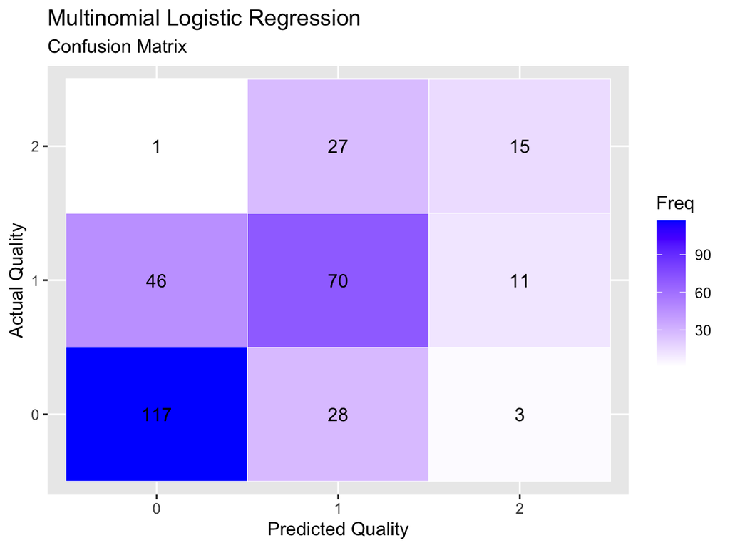

```r
# count every (predicted, actual) pair, with levels in the order 0, 1, 2
cm_counts <- table(
  Predicted = factor(predicted_classes,  levels = c("0", "1", "2")),
  Actual    = factor(test$quality_group, levels = c("0", "1", "2"))
)
confusion_matrix <- as.data.frame(cm_counts)

ggplot(confusion_matrix, aes(x = Predicted, y = Actual, fill = Freq)) +
  geom_tile(color = "white") +                          # one tile per cell
  geom_text(aes(label = Freq)) +                        # count in each tile
  scale_fill_gradient(low = "white", high = "blue") +   # darker = more wines
  labs(title = "Multinomial Logistic Regression",
       subtitle = "Confusion Matrix",
       x = "Predicted Quality", y = "Actual Quality")
```

Of the 43 good wines in the test set, 27 are predicted average and only 1 is predicted poor. Likewise, only 3 poor wines are predicted good. Most mistakes are between **neighboring** classes. This happens because the classes are ordered: a good wine is chemically closer to an average wine than to a poor one. The model doesn’t know about this ordering (see the Extension).

## 9.2 Accuracy and per-class metrics

`caret::confusionMatrix()` computes overall accuracy and one-vs-all metrics for each class. It expects the predicted and actual classes as factors with the same levels.

```r
test_y      <- factor(test$quality_group, levels = c("0", "1", "2"))
test_y_pred <- factor(predicted_classes,  levels = c("0", "1", "2"))

cm <- confusionMatrix(test_y_pred, test_y, mode = "everything")

cm$overall[c("Accuracy", "AccuracyNull")]
```

```
##     Accuracy AccuracyNull
##    0.6352201    0.4654088
```

```r
round(cm$byClass[, c("Precision", "Recall", "F1")], 3)
```

```
##          Precision Recall    F1
## Class: 0     0.713  0.791 0.750
## Class: 1     0.560  0.551 0.556
## Class: 2     0.517  0.349 0.417
```

The model classifies 63.5% of test wines correctly. The **no-information rate** (`AccuracyNull`) is 46.5%: the accuracy you would get by always guessing the largest class, poor. Section 9.5 tests whether the gap is real.

For each class:

- **Precision**: of the wines predicted to be in this class, the share that really are.
- **Recall**: of the wines really in this class, the share the model finds.
- **F1**: the harmonic mean of precision and recall.

Recall for good wines is only 0.35. Good wines are just 13.6% of the data, so the model gains little likelihood by getting them right. It predicts good only when it is very sure. On top of that, good wines overlap heavily with average wines in chemistry (Section 4.3).

## 9.3 Macro and weighted averages

To summarize the three classes with one number:

- The **macro average** is the plain mean across classes, so every class counts equally.
- The **weighted average** weights each class by its share of the test set, so large classes count more.

```r
# share of test wines in each class, in the order 0, 1, 2
weights <- as.numeric(prop.table(table(test_y)))

averaging_scores <- data.frame(t(cm$byClass)) %>%   # one column per class
  setNames(c("Poor", "Average", "Good")) %>%
  mutate(macro_avg    = (Poor + Average + Good) / 3,
         weighted_avg = weights[1] * Poor + weights[2] * Average + weights[3] * Good)

round(averaging_scores[c("Precision", "Recall", "F1"), ], 3)
```

```
##            Poor Average  Good macro_avg weighted_avg
## Precision 0.713   0.560 0.517     0.597        0.626
## Recall    0.791   0.551 0.349     0.564        0.635
## F1        0.750   0.556 0.417     0.574        0.627
```

Macro F1 (0.574) is lower than weighted F1 (0.627) because the weak good class counts fully in the macro average. With imbalanced data, **macro F1** is the more honest summary: a model can’t score well on it by ignoring the rare class.

A third option, the **micro average**, pools the counts across classes before computing the metric. When every wine gets exactly one label, micro precision, micro recall and micro F1 all equal accuracy (0.635), so they add nothing here. The script computes them anyway.

## 9.4 ROC curves and log loss

The metrics above only use the predicted class. ROC curves and log loss use the predicted **probabilities**.

First we put the actual classes and probabilities in one data frame with readable names:

```r
# rename probability columns by looking up each column's class code
class_label <- c("0" = "poor", "1" = "avg", "2" = "good")
probs <- as.data.frame(predicted_probabilities)
colnames(probs) <- paste0("pred_prob_", class_label[colnames(probs)])

results <- data.frame(
  actual = factor(recode(as.character(test_y),
                         "0" = "poor", "1" = "average", "2" = "good"),
                  levels = c("average", "poor", "good")),   # same order as the columns
  probs
)
head(results)
```

```
##   actual pred_prob_avg pred_prob_poor pred_prob_good
## 1   poor     0.2330562      0.7627124    0.004231411
## 2   poor     0.2516880      0.7414485    0.006863423
## 3   poor     0.3282177      0.5851580    0.086624221
## 4   poor     0.5046574      0.4375501    0.057792439
## 5   poor     0.2279021      0.7680358    0.004062119
## 6   poor     0.3775780      0.5075806    0.114841353
```

With three classes we draw one **one-vs-all** ROC curve per class: for example, poor vs. not poor, ranked by the predicted probability of poor.

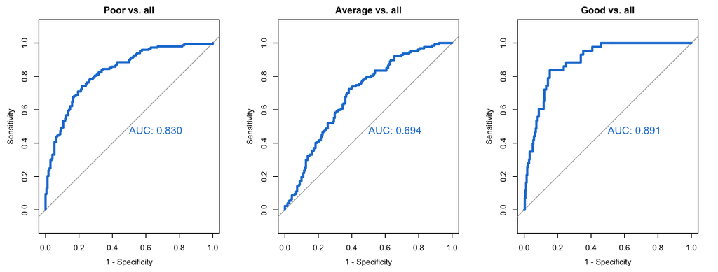

```r
plot_roc <- function(truth_class, prob_col, label) {
  roc_obj <- roc(results$actual == truth_class, results[[prob_col]], quiet = TRUE)
  plot(roc_obj,
       main = paste0(label, " vs. all"),
       col = "#1c7ed6", lwd = 3,
       print.auc = TRUE, print.auc.cex = 1.3,   # print the AUC on the plot
       legacy.axes = TRUE)    # x-axis = 1 - specificity; the gray line is chance
  as.numeric(auc(roc_obj))
}

par(mfrow = c(1, 3))   # three plots side by side
auc_poor <- plot_roc("poor",    "pred_prob_poor", "Poor")
auc_avg  <- plot_roc("average", "pred_prob_avg",  "Average")
auc_good <- plot_roc("good",    "pred_prob_good", "Good")
```

```r
par(mfrow = c(1, 1))

round(c(poor = auc_poor, average = auc_avg, good = auc_good), 3)
```

```
##    poor average    good
##   0.830   0.694   0.891
```

The AUC is the probability that a randomly chosen wine from the class gets a higher predicted probability than a randomly chosen wine outside it (0.5 = chance, 1 = perfect). Good has a high AUC even though its recall is low. The model *ranks* good wines well, but its probabilities rarely cross the point where good becomes the most likely class.

**Average has the lowest AUC** (0.69). It sits between the other two classes, so “not average” includes both better and worse wines. Moving a wine’s chemistry in either direction lowers its probability of average, which makes average hard to separate with one ranking.

```r
# columns must be listed in the same order as levels(results$actual)
mn_log_loss(results, truth = actual,
            pred_prob_avg, pred_prob_poor, pred_prob_good)
```

```
## # A tibble: 1 × 3
##   .metric     .estimator .estimate
##   <chr>       <chr>          <dbl>
## 1 mn_log_loss multiclass     0.761
```

**Log loss** is the average of $-\log(\text{probability given to the true class})$. Lower is better, and confident wrong predictions are penalized heavily. Guessing 1/3 for every class gives $\log 3 \approx$ 1.099, so our model’s probabilities are clearly informative.

## 9.5 Baseline and cross-validation

Is 63.5% accuracy actually better than always guessing poor?

```r
data.frame(model    = c("Always predict poor", "Multinomial logistic regression"),
           accuracy = round(c(cm$overall["AccuracyNull"], cm$overall["Accuracy"]), 3),
           row.names = NULL)
```

```
##                             model accuracy
## 1             Always predict poor    0.465
## 2 Multinomial logistic regression    0.635
```

```r
cm$overall["AccuracyPValue"]   # one-sided test: accuracy > no-information rate
```

```
## AccuracyPValue
##   8.455556e-10
```

The p-value is tiny, so the model clearly beats the baseline.

One test set gives one estimate. **10-fold cross-validation** on the training data gives a more stable one. We also tune `decay`, the L2 (ridge) penalty in `multinom()`. `decay = 0` is the unpenalized model we fit above.

```r
train_x <- as.data.frame(dplyr::select(train, -quality_group))
train_y <- factor(train$quality_group, levels = c("0", "1", "2"))

set.seed(123)   # reproducible fold assignment
cv_fit <- train(
  x = train_x, y = train_y,
  method     = "multinom",
  preProcess = c("center", "scale"),       # scaling redone inside each fold
  trControl  = trainControl(method = "cv", number = 10),
  tuneGrid   = expand.grid(decay = c(0, 0.001, 0.01, 0.1, 1)),
  trace      = FALSE                       # hide multinom's iteration log
)
round(cv_fit$results[, c("decay", "Accuracy", "Kappa")], 4)
```

```
##   decay Accuracy  Kappa
## 1 0.000   0.6253 0.3652
## 2 0.001   0.6253 0.3652
## 3 0.010   0.6253 0.3652
## 4 0.100   0.6261 0.3664
## 5 1.000   0.6261 0.3664
```

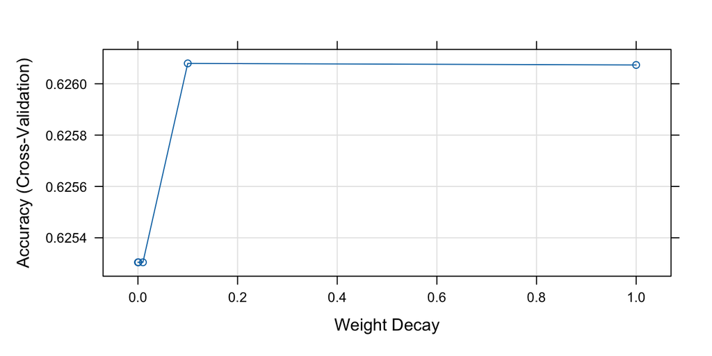

```r
plot(cv_fit)
```

Cross-validated accuracy is between 0.625 and 0.626 for every decay value. The plot looks dramatic only because its y-axis spans less than 0.001. The penalty makes no meaningful difference, **so we keep the unpenalized model**. CV accuracy is also close to our test accuracy, so the test result isn’t a lucky split.

# 10 Class imbalance

The model maximizes the likelihood over all training wines. Since good wines are rare, misclassifying them costs little, so the model rarely predicts good.

**Class weights** fix this by giving each training wine a weight inversely proportional to its class size:

$$w_i = \frac{n}{K \, n_{c(i)}},$$

where $n$ is the number of training wines, $K = 3$ is the number of classes and $n_{c(i)}$ is the size of wine $i$’s class. Each class then has the same total weight, $n/3$.

```r
counts <- table(train$quality_group)
round(nrow(train) / (3 * counts), 2)   # weight for each class
```

```
##
##    1    0    2
## 0.84 0.72 2.45
```

```r
w <- as.numeric(nrow(train) / (3 * counts[train$quality_group]))   # one weight per wine

model_w <- multinom(quality_group ~ ., data = train, weights = w,
                    maxit = 1000, trace = FALSE)
model_w$convergence   # 0 = converged
```

```
## [1] 0
```

```r
pred_w <- factor(predict(model_w, newdata = test, type = "class"),
                 levels = c("0", "1", "2"))
cm_w <- confusionMatrix(pred_w, test_y, mode = "everything")
cm_w_counts <- table(Predicted = pred_w, Actual = test_y)

# recall by class
data.frame(class             = c("poor", "average", "good"),
           recall_unweighted = round(cm$byClass[, "Recall"], 3),
           recall_weighted   = round(cm_w$byClass[, "Recall"], 3),
           row.names = NULL)
```

```
##     class recall_unweighted recall_weighted
## 1    poor             0.791           0.757
## 2 average             0.551           0.441
## 3    good             0.349           0.791
```

```r
# overall accuracy and macro F1
data.frame(model    = c("unweighted", "weighted"),
           accuracy = round(c(cm$overall["Accuracy"], cm_w$overall["Accuracy"]), 3),
           macro_f1 = round(c(mean(cm$byClass[, "F1"]), mean(cm_w$byClass[, "F1"])), 3))
```

```
##        model accuracy macro_f1
## 1 unweighted    0.635    0.574
## 2   weighted    0.635    0.611
```

Weighting more than doubles recall for good wines, from 0.35 to 0.79. Accuracy is the same (0.635) and macro F1 rises to 0.611. The cost is lower recall for average wines (0.44 vs. 0.55): the number of average wines called good rises from 11 to 33, and precision for good falls from 0.52 to 0.45 because the model now labels 76 wines good.

Which model is better depends on the goal. If finding good wines matters, for example for a buyer, the weighted model is the better choice. Weights change only how training wines count. The test set is never reweighted.

# 11 Multicollinearity

Predictors are **collinear** when they move together. We check the correlations in the training set (standardizing doesn’t change correlations):

```r
cor_matrix <- cor(train[predictors])

# the five most strongly correlated pairs, each listed once
as.data.frame(as.table(cor_matrix)) %>%
  filter(as.character(Var1) < as.character(Var2)) %>%
  mutate(abs_cor = abs(Freq)) %>%
  arrange(desc(abs_cor)) %>%
  head(5)
```

```
##                  Var1                 Var2       Freq   abs_cor
## 1 free sulfur dioxide total sulfur dioxide  0.6836951 0.6836951
## 2         citric acid        fixed acidity  0.6792542 0.6792542
## 3       fixed acidity                   pH -0.6760570 0.6760570
## 4             density        fixed acidity  0.6661538 0.6661538
## 5         citric acid     volatile acidity -0.5470393 0.5470393
```

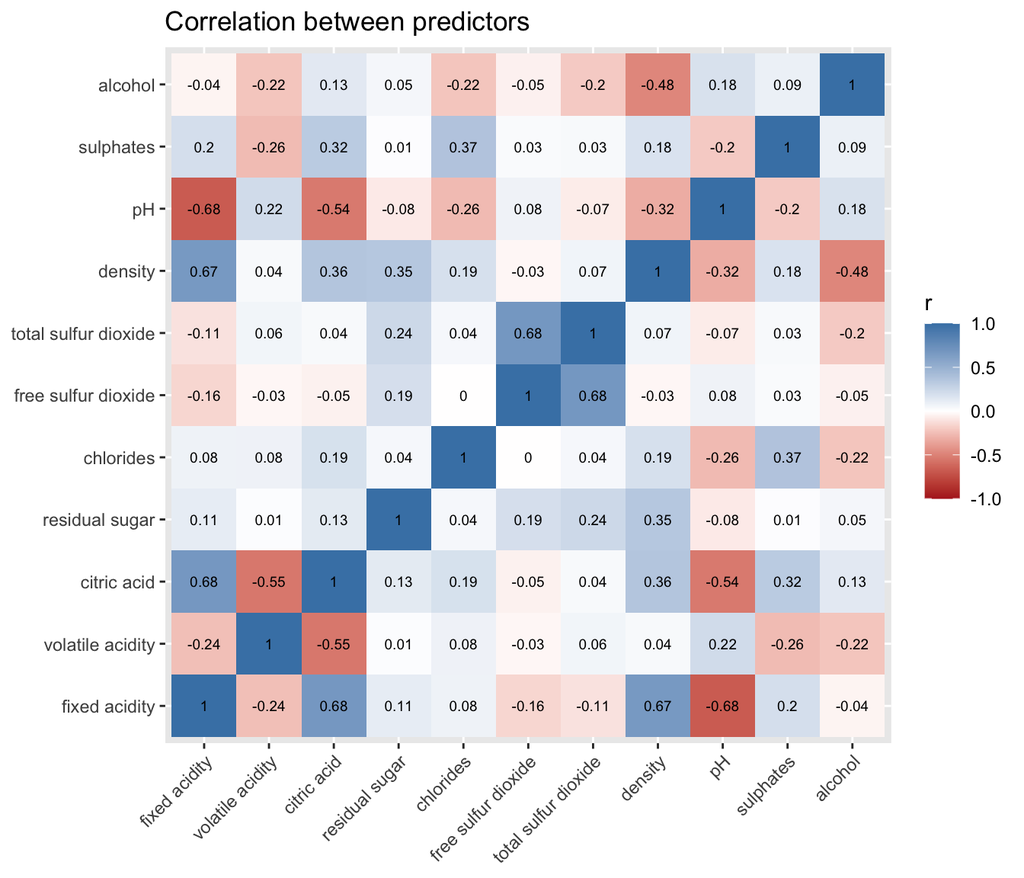

```r
# heatmap: blue = positive, red = negative
as.data.frame(as.table(cor_matrix)) %>%
  ggplot(aes(x = Var1, y = Var2, fill = Freq)) +
  geom_tile() +
  geom_text(aes(label = round(Freq, 2)), size = 2.5) +
  scale_fill_gradient2(low = "firebrick", mid = "white", high = "steelblue",
                       limits = c(-1, 1)) +
  labs(title = "Correlation between predictors", x = NULL, y = NULL, fill = "r") +
  theme(axis.text.x = element_text(angle = 45, hjust = 1))
```

The strongest pairs are free and total sulfur dioxide, and fixed acidity with citric acid, pH and density (all around $|r| \approx 0.68$). Density is also correlated with alcohol ($r \approx -0.48$).

When predictors are correlated, the model can’t tell which one deserves the credit. Coefficients can shift a lot, or even change sign, when a related predictor is added or dropped, and their standard errors grow. **Predictions are mostly unaffected.**

To see this, we refit the model without density:

```r
model_no_density <- multinom(quality_group ~ . - density, data = train,
                             maxit = 1000, trace = FALSE)

terms <- c("alcohol", "`fixed acidity`")   # multinom keeps backticks around names with spaces
data.frame(
  class        = rep(c("poor", "good"), times = 2),
  term         = rep(c("alcohol", "fixed acidity"), each = 2),
  coef_with    = round(as.vector(coef(model)[, terms]), 3),
  coef_without = round(as.vector(coef(model_no_density)[, terms]), 3),
  se_with      = round(as.vector(summary(model)$standard.errors[, terms]), 3),
  se_without   = round(as.vector(summary(model_no_density)$standard.errors[, terms]), 3)
)
```

```
##   class          term coef_with coef_without se_with se_without
## 1  poor       alcohol    -0.810       -0.832   0.126      0.090
## 2  good       alcohol     0.447        0.733   0.159      0.110
## 3  poor fixed acidity    -0.247       -0.209   0.200      0.124
## 4  good fixed acidity     0.539        0.076   0.244      0.155
```

```r
# test accuracy with and without density
pred_nd <- factor(predict(model_no_density, newdata = test, type = "class"),
                  levels = c("0", "1", "2"))
c(with_density    = mean(test_y_pred == test_y),
  without_density = mean(pred_nd == test_y))
```

```
##    with_density without_density
##       0.6352201       0.6257862
```

Without density, the fixed acidity coefficient for good vs. average drops from 0.54 to 0.08, nearly zero. The alcohol coefficient for good grows from 0.45 to 0.73. Every standard error shrinks. Test accuracy barely moves (0.626 vs. 0.635).

The lesson: with collinear predictors, **don’t read too much into any single coefficient**. If interpretation matters, drop or combine redundant predictors, or use a penalty. If you only need predictions, collinearity is a much smaller concern.

# 12 Extension

**Exercise: change the reference class.** Refit the model with poor as the reference (`relevel(train$quality_group, ref = "0")`).

1. Check that the predicted classes on the test set don’t change.
2. Find the RRR for alcohol in the good vs. poor equation.
3. Show that the same number comes from the original model as `exp(coef(model)["2", "alcohol"] - coef(model)["0", "alcohol"])`. Why does this work?

*Going further:* our model treats poor, average and good as unordered labels. Fit an ordinal logistic regression with `MASS::polr()`, which uses one set of coefficients plus two cutpoints, and compare its test accuracy and macro F1 with ours.

# 13 Conclusion

Multinomial logistic regression extends binary logistic regression to three or more classes by fitting one log-odds equation per non-reference class. On the red wine data:

- The model reaches 63.5% test accuracy, well above the 46.5% from always guessing poor, with macro F1 0.574.
- **Alcohol** and **sulphates** push wines away from poor and toward good. **Volatile acidity** pushes them toward poor.
- The rare good class is the hardest to predict. Class weights raise its recall from 0.35 to 0.79 with no change in accuracy, at the cost of lower recall for average wines.
- Correlated predictors such as density make individual coefficients unstable but barely affect predictions.

**Limitations.**

- The classes are imbalanced, and the cutoffs (≤ 5, 6, ≥ 7) are our choice. Different cutoffs would give different results.
- The model is linear in the log-odds, so it can’t capture interactions or curved effects without extra terms.
- The classes are ordered, but the model treats them as unordered labels.
- The data contain 240 duplicate rows, some of which may fall in both the training and test sets, so the test results may be slightly optimistic.
- Quality scores come from tasters and are subjective.

**Next steps:** fit an ordinal model (`MASS::polr()`), add interaction or spline terms, and compare against flexible classifiers such as random forests.

# 14 References

1. Cortez, P., Cerdeira, A., Almeida, F., Matos, T., & Reis, J. (2009). Modeling wine preferences by data mining from physicochemical properties. *Decision Support Systems*, 47(4), 547–553.
2. James, G., Witten, D., Hastie, T., & Tibshirani, R. (2021). *An Introduction to Statistical Learning* (2nd ed.), Section 4.3.5. Springer.
3. Agresti, A. (2013). *Categorical Data Analysis* (3rd ed.), Chapter 8. Wiley.
4. Venables, W. N., & Ripley, B. D. (2002). *Modern Applied Statistics with S* (4th ed.). Springer. (Source of the `nnet` package.)
5. Kuhn, M. (2008). Building predictive models in R using the caret package. *Journal of Statistical Software*, 28(5), 1–26.
6. Robin, X., et al. (2011). pROC: an open-source package for R and S+ to analyze and compare ROC curves. *BMC Bioinformatics*, 12, 77.